# Canadian Gridded Climate Dataset - NRCANmet

## Summary Description

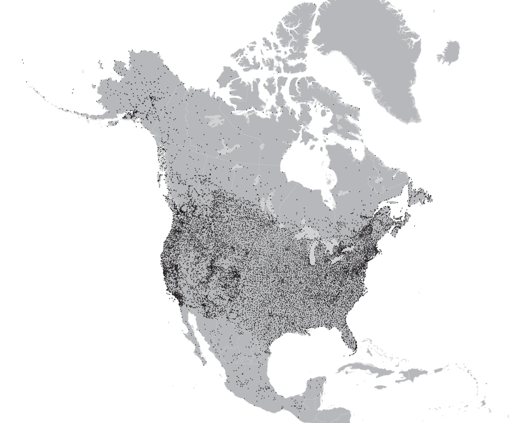

Temperature stations used in the ANUSPLIN interpolation for North America (from MacDonald *et al.* (2020))

## Dataset Characteristics

- **Current version:** No official versioning, see Expert Guidance. The latest version was generated in 2022.
- **Available variables:** temperature & precipitation (see variables section below
- **Temporal coverage**: 1950–2020
- **Temporal resolution**: Daily and monthly
- **Spatial coverage**: Canadian landmass (The latest version covers Can & US, check when this will be on PAVICS and modify spatial coverage accordingly!)
- **Spatial resolution**: ~10 km grid spacing (0.083°)
- **Data type**: Quality-controlled station observations interpolated using ANUSPLIN
- **Data format:** netCDF, GeoTIFF
- **Web references:**  
  NRCANmet data descriptions are provided on the Northern Climate Data Report and Inventory (NCDRI) Web Site for [temperature](https://nordata.physics.utoronto.ca/en/annexes-datasets-descriptions/71-temperature/anusplin-gridded-canadian-temperature-dataset/) and [precipitation](https://nordata.physics.utoronto.ca/en/annexes-datasets-descriptions/72-precipitation/anusplin-gridded-canadian-precipitation-dataset/).
- **Reference:**  
  MacDonald *et al.* (2020)
- **Contact:** Dan McKenney, NRCan

## When to use NRCANmet

- When you need information about **past climate**.
- When you only need **precipitation** and/or **near-surface temperature**.
- When you need a **spatially complete** and **temporally continuous** gridded product.
- When the region of interest is **well covered by in-situ measurements**.
- When you need an observational dataset that is consistent with future climate projections available on [**ClimateData.ca**](https://climatedata.ca/).

## Strengths and Limitations

### Key Strengths of NRCANmet

| Strength | Description |
| --- | --- |
| **Observation-based** | The dataset is entirely based on quality controlled observed data. |
| **High spatial resolution** | Provides detailed climate information at ~10 km resolution. |
| **Long-term coverage** | Spans over six decades, enabling comprehensive climate trend analyses. |
| **Reference dataset for ClimateData.ca** | The [ClimateData.ca](https://climatedata.ca) portal uses the PCIC-Blend version of NRCANmet as the reference dataset for the bias correction of the underlying climate projection data. |

### Key Limitations of NRCANmet

| Limitation | Description |
| --- | --- |
| **Temporal inconsistency** | Station availability and density varies over time, affecting data consistency over time. |
| **Interpolation limitations** | Accuracy depends on the density and distribution of input stations. |
| **Artefacts in the data** | The interpolation procedure occasionaly produces local artefacts of unrealistic values. |
| **Lack of real-time updates** | Dataset extends up to 2020, updates are irregular. |
| **Limited variables** | Focuses primarily on temperature and precipitation; other climate variables are not included. |

## Expert Guidance

**None(click to expand)**

The Canadian Gridded Climate Dataset (NRCANmet) is a widely used gridded dataset derived from observed station data, providing continuous climate and weather information in space and time. The long time period makes it useful for climate studies and it has been employed in the bias adjustment of climate model simulation data, namely the data backing the [ClimateData.ca](https://climatedata.ca/) web site. It was also used as the reference dataset in the bias adjustment of earlier versions of generic climate projection ensembles at Ouranos.

The ANUSPLIN algorithm used for the production of NRCANmet is designed to interpolate irregularly distributed station data and accounts for elevation variations, balancing fidelity to data with smoothness while avoiding overfitting. It produces smooth, realistic surfaces well suited for environmental modeling, agriculture, forestry, or hydrology studies (MacDonald *et al.* (2020)). The station data used for the NRCANmet dataset are quality controlled but not homogenized. Elevation data are used in the interpolation scheme. The fields show little to no systematic biases but locally erroneaous stations may propagate into the interpolation. By construction, precipitation events can not occur between two stations in the dataset. In a hydrological context this almost always reduces the amount of water in a watershed when using NRCANmet as input. Temperature values, on the other hand tend to have lower biases as compared to reanalysis which can have systematic bias. Nevertheless, reanalysis data often appear to better represent orographic influence on climate variables.

Like any such interpolated data it is highly dependent on the quality of the input data and its reliability diminishes with the availability of station data or the distance to the latter. Particularly in areas of sparse station networks like the Canadian North, the interpolation is less capable of capturing local variation between stations far apart. This is particularly the case for precipitation since, other than temperature, it is not continuous in time and space. Thus, Hutchinson *et al.* (2009) advise caution when using daily precipitation data and particularly theirextremes. Further, the interpolation algorithm may introduce artefacts of unrealistic values in the data fields, thus quality checks may be warranted. Guidance on performing such quality checks can be found in Rondeau-Genese & Braun (2020) (page 16ff; in French only).

#### Versioning

##### NRCANmet

Different versions of the dataset have been published but as of this writing no offical versioning of the dataset has been established. The versions differ in the version of the ANUSPLIN algorithm, in the stations used and the temporal coverage as more recent years were produced in each iteration. This lack of official versioning as led different organizations to have an internal versioning (for ex. v1 at Ouranos is not the same as v1 at PCIC). One way to disentangle this inconsistent naming is to look at when the data released. Here is a (likely incomplete) list of versions available:

- v2012: Called v1 at PCIC, used in CanDCS-U5 et CanDCS-U6, covers 1950-2010
- v2014: Called v1 at Ouranos, reference dataset for Ouranos ScenGen climate projections, covers 1950-2013
- v2018: Called v2 at Ouranos, covers 1950-2017
- v2018PB: Called v2 at PCIC. A modified version of v2018 was used in PCIC-Blend temperatures. The modifications include a correction of temperature inversion, where Tmin > Tmax which sometimes leads to temperature at a grid point much higher than their neighbors. It should be noted that the conversion from K to degC was using 273 K, instead of 273.15 K.
- NRCANmet-Adjusted v2021: used in PCIC-Blend precipitation, cover 1950-2015 (MacDonald *et al.* (2021))
- v2022: covers 1949-2020

The versions are generally very similar in their temperature values, with later versions having less temperature reversals. Regarding precipitation, the v2018 version is somewhat dryer than v2014. For Northern and Eastern stations, biases compared to stations are lower for v2018. The dataset is particulary dryer over the western mountains which motivated the generation of PCIC-Blend, a combination of NRCANmet with a distinct gridded dataset over western Canada and the north-western US .

##### PCIC-Blend

PCIC-Blend is a combination of three different station-based gridded climate datasets:

1. NRCANmet-Adjusted v2021
2. NRCANmet v2018PB
3. PNWNAmet

Over western Canada the performance of NRCANmet is inferior to PNWNAmet when compared to high quality station observations. PNWNAmet values in western Canada were combined with the NRCANmet v2018PB temperature and NRCANmet-Adjusted v2021 precipitation values in central and eastern Canada to produce PCIC-Blend (Werner *et al.* (2019)). For more information see the [“Historical Data” section](https://climatedata.ca/about/our-data/) on ClimateData.ca.

When comparing temperature data processed by PCIC and Ouranos, a mean difference of 0.15 ˚C was found. This could be traced back to the adjustment of the raw data provided in Kelvin using 273 ˚C and 273.15 ˚C by PCIC and Ouranos respectively.

## Variables available in NRCANmet

*For details click on variable group to uncollapse*

**NoneTemperature**

- Daily maximum temperature (°C)
- Daily minimum temperature (°C)
- Monthly maximum temperature (°C)
- Monthly minimum temperature (°C)
- Pentad (°C)
- Climatological means (°C)

**NonePrecipitation**

- Daily total precipitation (mm)
- Monthly total precipitation (mm)
- Pentad (°C)
- Climatological means (°C)

## Data Access

NRCANmet gridded data is freely available upon contact with Dr. Dan McKenney, Canadian Forest Service, Natural Resources Canada, dan.mckenney@canada.ca

The dataset is also available on [PAVICS](https://pavics.ouranos.ca/datasets.html#b). To avoid downloading very large datasets in their entirety PAVICS allows partial/regional extraction and provides a [tutorial](https://pavics-sdi.readthedocs.io/en/latest/notebooks/CaSR_basic.html) to do so, using the CaSR reanalysis as an example . With a free PAVICS user account, the Jupyter notebook with the Python code in the tutorial can be [directly used on PAVICS](https://pavics.ouranos.ca/jupyter/hub/user-redirect/lab/tree/tutorial-notebooks/CaSR_basic.ipynb).

## References

**(click to expand)**

Hopkinson, R. F., McKenney, D. W., Milewska, E. J., Hutchinson, M. F., Papadopol, P., & Vincent, L. A. (2011). [Impact of aligning climatological day on gridding daily maximum–minimum temperature and precipitation over canada](https://doi.org/10.1175/2011JAMC2684.1). *Journal of Applied Meteorology and Climatology*, **50**(8), 1654–1665.

Hutchinson, M. F., McKenney, D. W., Lawrence, K., … Papadopol, P. (2009). [Development and testing of canada-wide interpolated spatial models of daily minimum–maximum temperature and precipitation for 1961–2003](https://doi.org/10.1175/2008JAMC1979.1). *Journal of Applied Meteorology and Climatology*, **48**(4), 725–741.

MacDonald, H., McKenney, D. W., Papadopol, P., Lawrence, K., Pedlar, J., & Hutchinson, M. F. (2020). [North american historical monthly spatial climate dataset, 1901–2016](https://doi.org/10.1038/s41597-020-00737-2). *Scientific Data*, **7**(1), 411.

MacDonald, H., McKenney, D. W., Wang, X. L., … Hutchinson, M. F. (2021). [Spatial models of adjusted precipitation for canada at varying time scales](https://doi.org/10.1175/JAMC-D-20-0041.1). *Journal of Applied Meteorology and Climatology*, **60**(3), 291–304.

McKenney, D. W., Hutchinson, M. F., Papadopol, P., … Owen, T. (2011). [Customized spatial climate models for north america](https://doi.org/10.1175/2011BAMS3132.1). *Bulletin of the American Meteorological Society*, **92**(12), 1611–1622.

Rondeau-Genese, G., & Braun, M. (2020). *Production des scénarios climatiques pour les projets : Impact des changements climatiques sur les débits au québec (cQ2) et la thématique évolution du climat du projet de soutien à INFO-crue*, Ouranos Inc. Retrieved from https://www.ouranos.ca/sites/default/files/2023-03/proj-201419-post-traitement-projections-510035-rapport-technique.pdf

Werner, A. T., Schnorbus, M. A., Shrestha, R. R., … Anslow, F. (2019). [A long-term, temporally consistent, gridded daily meteorological dataset for northwestern north america](https://doi.org/10.1038/sdata.2018.299). *Scientific Data*, **6**(1), 180299.